# Introduction

Data for this project are drawn from the National Survey on Drug Use and Health (NSDUH). The NSDUH is directed by the Substance Abuse and Mental Health Services Administration (SAMHSA), an agency in the U.S. Department of Health and Human Services (DHHS). NSDUH is the leading source of U.S. statistics regarding illicit drug use, alcohol, tobacco, and mental health issues among U.S. civilians. This database monitors trends in specific substance use and mental health issues. NSDUH has been conducted yearly since 1971 and thus provides important insights into trends in substance use and misuse beyond describing the current situation.

Surveys like the NSDUH provide an opportunity to identify potential sub-populations at risk for substance misuse and consequent or comorbid health problems. This supports government agencies’ efforts to develop prevention campaigns and refine healthcare and social services. The aim of this project is to investigate associations based on substance use behavior demographic characteristics of consumers, and mental health issues.

## Data gathering

### Data Source

The database can be accessed from the [Substance Abuse and Mental Health Services Administration (SAMHSA) server](https://www.datafiles.samhsa.gov/study/national-survey-drug-use-and-health-nsduh-2019-nid19014). This database is a survey conducted in 2019 of U.S. civilians aged 12 years and older.

In total 67,625 individual observations were recorded in the survey, of which 56,136 are publicly available. Each individual observation contains a total of 2,741 raw, reviewed, imputed and recoded data variables (features) related to substance use behaviors, demographics and mental health issues. The selected features as well as the number of observations have been verified during the validation and transformation process of the data during the following phases. More detailed information about the data gathering and pre-processing process is available on the [official survey's codebook](https://www.datafiles.samhsa.gov/sites/default/files/field-uploads-protected/studies/NSDUH-2019/NSDUH-2019-datasets/NSDUH-2019-DS0001/NSDUH-2019-DS0001-info/NSDUH-2019-DS0001-info-codebook.pdf)

### Data Fetching

**FetchData service class**

The project source code contains the data fetching functionality as a separate `FetchData` service class. It contains the basic `fetch_db_and_write_tsv_file()` method which is responsible for handling the fetch request to the SAMHSA server in order to access the required raw data file in zip format. The retrieved file is stored locally in the project data directory.

If the preprocessed database is required instead, it is recommended to call the `project_dataframe(self, nrows=None, features=None, as_labels=False)` method from the `DataService` class. This class automatically triggers the fetch, write and access to the preprocessed information. Further details regarding the use of the DataService class as well as of other important service classes can be found in the data transformation section described in the subsequent chapters.

## Data Inspection and Validation

During the inspection process, problems associated with inconsistencies, non-grouping, and poor clarity of the variables and values in the existing data were identified. These limitations were addressed by applying a series of countermeasures described in the data consistency constraints and countermeasures section.

### Data Consistency Constraints and Countermeasures

**Inconsistencies in standard code conventions**

Inconsistencies were identified in the standard code conventions that were applied to answer categories associated with a specific feature. These code inconsistencies are due to differences in standard coding conventions from previous surveys (NSDUH was first conducted in 1971) that should be preserved in order to ensure compatibility across time. Usually these inconsistencies are present in data that have been flagged as being invalid or as part of the logical editing process. An example of these option code inconsistencies *(to reference for example the answer option "Never used [Drug(s) of Interest]")* to a question related to a specific feature *(such as "Have you ever tried even once substance X" or how old where you when you the first time you had used substance X)* could be represented as 91 or 991 or 9991, etc. where all numerical options mean the same. These inconsistencies are analogous to similar options such as 94 or 994 or 9994, etc for *"Don't Know"*.

**Manual Feature Grouping**

Different features may refer to the same question of substance-use behavior with the difference that each feature connects that question to a specific substance. That is why, for example, for the question "Have you ever tried..." there are at least 13 substances, that is, 13 different features that relate to it. The disadvantage here is that the features are not grouped according to the question they address, nor is there a standard coding that can be used together with string matching techniques as regular expression for automatic detection, i.e. grouping them. Consequently, the grouping work must be done manually in its whole. An example of this inconvenience is given by the group of features such as 'CGR30USE', 'ALCDAYS',' MJDAY30A', etc. which are related to the question about the number of days of consumption of a substance in the last 30 days prior to the survey for substance groups cigarette ('CGR'), alcohol ('alc'), and marijuana ('MJ'), respectively.

**Incomprehensible Feature Names and Values**

Another drawback is the inability to understand at first glance (by means of visually inspecting the data) the meaning of the lables for each of the available features. This drawback is illustrated by looking at the original feature lablel 'DSTNGD30' which does not give any clues that would enable the reader to identify its meaning without consulting a codebook or other sorts of documentation. This feature label refers to a mental health condition (felt down, no good or worthless) experienced by a person during the last month. This inconvenience is even more pronounced when looking at the available answers for this feature. There is an option level starting at 1 that will be interpreted as 'All of the time' up to 5 interpreted as 'None of the time'. Additionaly there are other ‘valid’ options such as 85 for 'Bad data Logically assigned' or 98 for 'Refused'. Another issue has to do with the constant (and very likely unnecessary) computation performance required to transform such data into understandable linguistic schemes like English every time it is required. The following table contains other examples for this issue.

| Feature label | Feature question |
| --- | --- |
| ECSTMOLLY | Have you ever, even once, used 'Ecstasy' or 'Molly,' also known as MDMA? |

**Available answers for ECSTMOLLY**

| "1" | "Yes" |
| --- | --- |
| "2" | "No" |
| "3" | "Yes LOGICALLY ASSIGNED" |
| "85" | "BAD DATA Logically assigned" |
| "91" | "NEVER USED" |
| "94" | "DON'T KNOW" |
| "97" | "REFUSED" |

**Available answers for CIGEVER**

| "1" | "Yes" |
| --- | --- |
| "2" | "No" |

**Countermeasures**

A `FeatureService` class containing all available `FeatureGroup` instances has been created. `FeatureGroup` type classes group together features that relate to a same question concerning substance use, demographics, or mental health issues. Each FeatureGroup class type encapsulates each individual feature as a single object containing (among others) the question it covers as well as the range of options according to the individual standard codes of the original database. These classes also contain a number of methods to make the required parsing of the individual inconsistent standard codes into a standard format that is applicable to all feature options in the resulting database.

Finally, extension classes consisting of decorators to be used in pandas.DataFrame or pandas.Series objects have been created allowing data parsing according to the indicated parameters. The following section describes the workflow of the data transformation process in terms of the most representative classes that are responsible for the execution the preprocessing and selection procedures required by this project.

### Data Validation

For data validation, the resulting preprocessed variables and values were checked against those described in the official database codebook. For this, several tools as described in the explorative analysis section of the pre-processed data have been used.

## Data Transformation

The data transformation process is split into two main data transformation phases. The first one refers to a variety of raw data reduction and cleaning operations conducted on the original dataset. Initially, a reduction of the dimensionality of the database has been carried out by extracting the features under consideration for the subsequent analyses. Then the standard convention codes that are used for the value meanings (responses) for each selected feature were unified and any found inconsistencies were replaced by -1. Lastly, the original feature labels and ordinal feature values were replaced by understandable English language and inconsistent values were replaced by legitimate NaN datatype. Both preprocessed versions (i.e., the preprocessed version with and without converting the feature labels into understandable English) were written and locally stored in the project data directory.

The second data transformation phase concerns the disposition of transformation methods from the preprocessed data to the lists of nodes and edges that are required for generating the networks and exporting the data in gephi or csv format if desired. Here it is worth mentioning that the use of gephi has been intentionally avoided since networkx provides all the necessary functionality for the subsequent analysis.

### Service Classes

#### FeatureGroupInterface

| Feature Group Class | Description |
| --- | --- |
| FeatureDaysOfUseLast30Days(FeatureGroupInterface) | Contains all the features related to the number of days of substances used during the past month by the participant prior to their participation in the survey |
| FeatureEverUsed(FeatureGroupInterface) | Includes all the features related to substances ever used by the participant at some point in their life |
| FeatureDemographics(FeatureGroupInterface) | Groups some demographic characteristics of the participant (age, sex, poverty level, etc.) |
| FeatureMentalHealth(FeatureGroupInterface) | Contains some mental health related issues experienced by the participant during the past month prior to their participation in the survey |

#### FeatureService

A `FeatureService` instance is all it takes to access all FeatureGroup type classes.

#### DataService

The `DataService` class is the main class for accessing the data. This class contains the main method `project_dataframe(self, nrows=None, features=None, as_labels=False)` returning the preprocessed data used throughout the project as `pandas.DataFrame`. In addition to this, this class contains instances of the previously mentioned classes as well as other useful data service classes for complementary data visualisations (such as diverse interactive charts and dataframes).

#### NetworkService

The `NetworkService` class is the main class for accessing data, graphics and other algorithms related to the networks under analysis. This class has as attributes the `DataService` class as well as the `SubstanceNetworkService` and `PeopleNetworkService` classes. The two latter classes are responsible for the transformation of the preprocessed data into networkx compatible node and edges lists and attributes.

The following figure illustrates a minimalized version of the data gathering and transformation flow with the most important classes and methods

[figure not shown]

### Access the preprocessed data

There are two ways for accessing preprocessed data from scratch. The first way is by running this jupyter notebook and the second one is by executing the `main.py` script. Both files can be found in the root directory of this project.

If you want to access the data in an external script or jupyter notebook and want to access the preprocessed database you need to import the class `DataService` and run its `project_dataframe()` function. If you are also interested in accessing the available networks you can import the `NetworkService(dataservice_instance)` and call the desired methods. Keep in mind that you need to pass a `DataService()` instance inside the `NetworkService` parameter in order to perform the desired operations. The following provides the code that is to be found in the `main.py` script file

```
if __name__ == "__main__":
    from services.networkservice import NetworkService
    from services.dataservice import DataService
    ns = NetworkService(DataService())
    # Accesses the preprocessed dataset by calling the dataService instance inside the networkService class
    dataframe = ns.ds.project_dataframe(nrows=2)
    print('===Preprocessed database (Version 1)===\n\n', dataframe.head())
    print(dataframe.shape)
    # Accesses the preprocessed dataset with data features transformed into understandable english language
    # This whole project is based on this dataframe variant!
    dataframe = ns.ds.project_dataframe(as_labels=True)
    print('===The (MAIN) preprocessed project database (Version 2)===\n\n', dataframe.head())
    print(dataframe.shape)
    # Accesses the substances used in last 30 days networkx graph
    used_in_last_30_days_graph = ns.substance_used_in_last_30d_network(dataframe=dataframe)
    print('\n', ns.nx.info(used_in_last_30_days_graph), '\n')
    # Accesses the substance ever used networkx graph
    ever_used_graph = ns.substance_ever_used_network(dataframe=dataframe)
    print(ns.nx.info(ever_used_graph), '\n')
    # Accesses the people networkx graph
    people_graph = ns.people_network(dataframe=dataframe)
    print(ns.nx.info(people_graph), '\n')
    # Accesses the demographics feature group (this is analogue to the rest of available featuregroups:
    #   Other available feature groups= [ever_used, last_30_days_use, mental_health]
    demographic_features = ns.ds.feature_service.features['demographics'].feature_keys(as_labels=True)
    print(demographic_features)
    # Now the dataframe can be reduced by simply passing the retrieved features as parameters
    print(dataframe[demographic_features].head(2))
```

## Explorative Data Analysis with the Preprocessed Dataset

We start showing the sequence of actions taken from the raw data aquisition up to the data transformation processes. Finally a diverse range of descriptive analyses of the preprocessed data have been carried out aiming to get an overall picture of the data structure and meaning.

### Data Fetching and Preprocessing

```python
# Required packages
from services.dataservice import DataService
from services.networkservice import NetworkService
# For this jupyter notebook only
import networkx as nx
import matplotlib.pyplot as plt
import pandas as pd
import seaborn as sns
```

```python
# Main service class for accesing and preprocessing the original database
ds = DataService()
# Main service class for accesing the available network graphs
ns = NetworkService(ds)
```

```python
# The original database contains a total of 2741 columns (features) and 56136 rows (individual observations).
# As an example, the first five rows of the original file are read and displayed
raw_dataframe = ds.read_original_tsv_file(nrows=5)
raw_dataframe.head()
```

```
Reading data from dataset file...
Dataframe of original database was sucessfully read.
```

|  | QUESTID2 | FILEDATE | CIGEVER | CIGOFRSM | CIGWILYR | CIGTRY | CIGYFU | CIGMFU | CIGREC | CIG30USE | ... | POVERTY3 | TOOLONG | TROUBUND | PDEN10 | COUTYP4 | MAIIN102 | AIIND102 | ANALWT_C | VESTR | VEREP |
| --- | --- | --- | --- | --- | --- | --- | --- | --- | --- | --- | --- | --- | --- | --- | --- | --- | --- | --- | --- | --- | --- |
| 0 | 43295143 | 10/09/2020 | 1 | 99 | 99 | 13 | 9999 | 99 | 4 | 93 | ... | 3 | 2 | 2 | 2 | 2 | 2 | 2 | 6613.865847 | 40004 | 2 |
| 1 | 65095143 | 10/09/2020 | 2 | 99 | 99 | 991 | 9991 | 91 | 91 | 91 | ... | 3 | 2 | 2 | 2 | 2 | 2 | 2 | 6321.580570 | 40003 | 1 |
| 2 | 49405143 | 10/09/2020 | 1 | 99 | 99 | 22 | 9999 | 99 | 4 | 93 | ... | 3 | 2 | 2 | 2 | 2 | 2 | 2 | 5045.607492 | 40008 | 1 |
| 3 | 51015143 | 10/09/2020 | 2 | 99 | 99 | 991 | 9991 | 91 | 91 | 91 | ... | 1 | 2 | 2 | 2 | 2 | 2 | 2 | 2419.558820 | 40031 | 1 |
| 4 | 31825143 | 10/09/2020 | 2 | 99 | 99 | 991 | 9991 | 91 | 91 | 91 | ... | 3 | 2 | 2 | 2 | 2 | 2 | 2 | 575.225454 | 40010 | 2 |

5 rows × 2741 columns

**Data Preprocessing (step 1)**

As mentioned before, a series of classes were created in order to preprocess the original dataset. The project specific features are now selected, inconsistent code conventions have been generalized and all invalid data have been replaced by -1.

```python
preprocessed_dataframe_1 = ds.project_dataframe(as_labels=False, nrows=5)
# The dataframe features have been now reduced to 69. By the end of this project some of them did not make part of the analysis
preprocessed_dataframe_1.head()
```

|  | CIGEVER | CIGTRY | CGR30USE | ALCEVER | ALCTRY | ALCDAYS | MJEVER | MJAGE | MJDAY30A | COCEVER | ... | DSTCHR30 | DSTEFF30 | DSTNGD30 | AGE2 | HEALTH | IRSEX | CATAG6 | NEWRACE2 | IRWRKSTAT18 | POVERTY3 |
| --- | --- | --- | --- | --- | --- | --- | --- | --- | --- | --- | --- | --- | --- | --- | --- | --- | --- | --- | --- | --- | --- |
| 0 | 1 | 13 | -1 | 1 | 10 | 20 | 1 | 21 | -1 | -1 | ... | 3 | 2 | 4 | 15 | 2 | 1 | 4 | 1 | 1 | 3 |
| 1 | -1 | -1 | -1 | 1 | 18 | -1 | -1 | -1 | -1 | -1 | ... | 5 | 5 | 5 | 17 | 2 | 0 | 6 | 5 | 1 | 3 |
| 2 | 1 | 22 | -1 | 1 | 21 | 1 | 1 | 20 | -1 | -1 | ... | 5 | 5 | 5 | 14 | 2 | 1 | 3 | 1 | 1 | 3 |
| 3 | -1 | -1 | -1 | 1 | 15 | -1 | -1 | -1 | -1 | -1 | ... | 4 | 5 | 5 | 9 | 3 | 0 | 2 | 1 | 4 | 1 |
| 4 | -1 | -1 | -1 | 1 | 17 | -1 | -1 | -1 | -1 | -1 | ... | 4 | 4 | 3 | 7 | 2 | 1 | 2 | 1 | 4 | 3 |

5 rows × 69 columns

**Data Preprocessing (final step)**

The final raw data transformation phase consisted in replacing the feature labels and options with understandable English language labels as well as replacing the invalid data by NaN datatypes. Keep in mind that this is the data that is meant to be used along the next data analysis steps.

The preprocessed data can be reprocessed by giving as_labels=True as a parameter inside the function `project_dataframe(as_labels=True)` included in the `DataService` class.

Some of the advantages of this approach are the easy visualization/recognition of the available features and what they represent as well as the reduction of repeated data parsing calculations required for the visualization of charts, networks and dataframes.

```python
# Returns the preprocessed data features and values in understandable english language
dataframe = ds.project_dataframe(as_labels=True, nrows=None)
dataframe.head()
```

|  | cigarette ever used | cigarette first use age | Days of cigarette use in past month | alcohol ever used | alcohol first use age | Days of alcohol use in past month | marijuana ever used | marijuana first use age | Days of marijuana use in past month | cocaine ever used | ... | felt sad in past month | felt like everything was an effort in past month | felt down, no good or worthless in past month | age | health | sex | age category | race | employment status | poverty level |
| --- | --- | --- | --- | --- | --- | --- | --- | --- | --- | --- | --- | --- | --- | --- | --- | --- | --- | --- | --- | --- | --- |
| 0 | yes | 13.0 | NaN | yes | 10.0 | 20.0 | yes | 21.0 | NaN | NaN | ... | Some of the time | Most of the time | A little of the time | between 35 and 49 years old | Very good | Male | 35 - 49 Years Old | NonHisp White | Employed full time | Income More Than 2X Fed Pov Thresh |
| 1 | NaN | NaN | NaN | yes | 18.0 | NaN | NaN | NaN | NaN | NaN | ... | None of the time | None of the time | None of the time | 65 years old or older | Very good | Female | 65 or Older | NonHisp Asian | Employed full time | Income More Than 2X Fed Pov Thresh |
| 2 | yes | 22.0 | NaN | yes | 21.0 | 1.0 | yes | 20.0 | NaN | NaN | ... | None of the time | None of the time | None of the time | between 30 and 34 years old | Very good | Male | 26 - 34 Years Old | NonHisp White | Employed full time | Income More Than 2X Fed Pov Thresh |
| 3 | NaN | NaN | NaN | yes | 15.0 | NaN | NaN | NaN | NaN | NaN | ... | A little of the time | None of the time | None of the time | 20 years old | Good | Female | 18 - 25 Years Old | NonHisp White | Other (incl. not in labor force) | Living in Poverty |
| 4 | NaN | NaN | NaN | yes | 17.0 | NaN | NaN | NaN | NaN | NaN | ... | A little of the time | A little of the time | Some of the time | 18 years old | Very good | Male | 18 - 25 Years Old | NonHisp White | Other (incl. not in labor force) | Income More Than 2X Fed Pov Thresh |

5 rows × 69 columns

**Project feature groups**

The features used in this project have been grouped into different categories. The following is a dictionary object containing all available FeatureGroups.

```python
feature_groups = ds.feature_service.features
print(*feature_groups.keys(),sep='\n')
```

```
age_first_use
ever_used
demographics
last_30_days_use
mental_health
```

## Explorative Analyses

### Description of the population

As stated above, the dataset contains data of 56,136 participants. The participants will be described based on an interactive bar chart depicting the distribution of age categories by gender as well as race by gender across the sample.

#### Number of people by age category and sex

The most sampled age categories are adolescents (12-17 ys) with 6,541 females and 6,856 males, as well as young adults (18-25 ys) with 7,183 females and 7,043 males. Least frequently, people of ages 65 and older were surveyed with 2,142 females and 1,756 males.

```python
age_by_sex_df, age_by_sex_chart = ds.demographics_service.age_by_sex_df_and_chart(dataframe=dataframe)
with pd.option_context('display.max_rows', None, 'display.max_columns', None):
    age_by_sex_chart.display()
    display(age_by_sex_df)
```

[interactive chart not shown]

|  | age category | sex | people |
| --- | --- | --- | --- |
| 0 | 12 - 17 Years Old | Female | 6541 |
| 1 | 12 - 17 Years Old | Male | 6856 |
| 2 | 18 - 25 Years Old | Female | 7183 |
| 3 | 18 - 25 Years Old | Male | 7043 |
| 4 | 26 - 34 Years Old | Female | 4664 |
| 5 | 26 - 34 Years Old | Male | 3937 |
| 6 | 35 - 49 Years Old | Female | 6169 |
| 7 | 35 - 49 Years Old | Male | 4965 |
| 8 | 50 - 64 Years Old | Female | 2649 |
| 9 | 50 - 64 Years Old | Male | 2231 |
| 10 | 65 or Older | Female | 2142 |
| 11 | 65 or Older | Male | 1756 |

#### Number of people by race and sex

The most sampled race categories are non-hispanic white people with 16,746 females and 15,343 males and the two race categories with the least number of observations are the group of native americans, native alaskans and native hawaiians with 383 females and 369 males as well as the group of other pacific islanders (Samoans, Chamorros, Fijians, Palauans and Tongans) with 148 females and 144 males. These last two groups are used for the creation and analysis of the people network described later in the social network analysis section.

```python
race_by_sex_df, race_by_sex_chart = ds.demographics_service.race_by_sex_df_and_chart(dataframe=dataframe)
with pd.option_context('display.max_rows', None, 'display.max_columns', None):
    race_by_sex_chart.display()
    display(race_by_sex_df)
```

[interactive chart not shown]

|  | race | sex | people |
| --- | --- | --- | --- |
| 0 | Hispanic | Female | 5676 |
| 1 | Hispanic | Male | 5172 |
| 2 | NonHisp Asian | Female | 1372 |
| 3 | NonHisp Asian | Male | 1325 |
| 4 | NonHisp Black/Afr Am | Female | 3912 |
| 5 | NonHisp Black/Afr Am | Male | 3344 |
| 6 | NonHisp Native Am/AK Native | Female | 383 |
| 7 | NonHisp Native Am/AK Native | Male | 369 |
| 8 | NonHisp Native HI/Other Pac Isl | Female | 148 |
| 9 | NonHisp Native HI/Other Pac Isl | Male | 144 |
| 10 | NonHisp White | Female | 16746 |
| 11 | NonHisp White | Male | 15343 |
| 12 | NonHisp more than one race | Female | 1111 |
| 13 | NonHisp more than one race | Male | 1091 |

### Exploratory analysis of individuals based on substances ever used

When using the characteristic of substance ever used, we want to know the percentage of people who have indicated to have consumed any of the investigated substances at some time in their lives with respect to the total observations. People who have used the substance at least once in their life are considered consumers (regardless of whether they are experimenters, abusers or (ex)dependents).

In the next section we will first focus on analyzing the proportion of substance ever used cases for the entire sample and then analyze specific substance use cases according to each age category.

#### Proportion of cases of substances ever consumed in life by all ages with respect to the total number of observations

To calculate the proportion of cases of a specific substance used at some time in life, the total number of people who have declared to have consumed that substance is summed up and then this value is divided by the total number of people surveyed

$$\%\ ever\ used\ cases_{substance\ x} = \frac{total\ affirmative\ cases}{number\ of\ people\ surveyed}$$

Where $substance\_x$ is one of the investigated substances

A peculiarity found in the analysis is that marijuana consumption is almost equivalent to cigarette consumption. One possible reason for this may be that over the past years, the consumption of marijuana has become legal in some U.S. states. In Switzerland, for instance, we would expect marijuana use - the consumption of an illegal substance - to be lower than cigarette use - the consumption of a legal substance.

```python
ever_used_df, ever_used_chart = ds.ever_used_service.all_substances_df_and_chart(dataframe=dataframe)

print("Percentage of substance ever used in life by people aged 12 and older")
with pd.option_context('display.max_rows', None, 'display.max_columns', None):
    display(ever_used_df.loc['All ages', ever_used_df.columns != 'total people'].sort_values(
    ascending=False).map(
    lambda x : round(x*100,2)).to_frame().rename(
    columns={'All ages': '%'}))
```

```
Percentage of substance ever used in life by people aged 12 and older
```

|  | % |
| --- | --- |
| alcohol | 71.43 |
| cigarette | 45.73 |
| marijuana | 44.15 |
| tranquilizers | 17.49 |
| hallucinogens | 14.58 |
| stimulants | 13.35 |
| cocaine | 11.78 |
| sedatives | 9.85 |
| inhalants | 9.56 |
| pain relievers | 9.31 |
| methamphetamine | 4.54 |
| crack | 2.62 |
| heroin | 1.73 |

#### Interactive bar graph of substances ever consumed by age category

The following altair bar graph shows a summary of all cases of substance ever consumed for each age category. You can hover over each bar to see detailed information about each use case and age category. In addition to this you can select one of the age category options included in the dropdown for a more detailed view.

In the “Age groups stacked” view, we can clearly see that substance use dramatically increases from adolescence (12-17 ys) to young adulthood (18-25 ys). For example, the proportion of respondents who have ever consumed alcohol increases from 27.9% in adolescents to 79.8% of young adults. A similar age-dependent development in substance use can be observed across the other substance categories. Some adolescents have already experimented with a specific substance, but the proportion of respondents who have ever used it generally increases notably in young adulthood and then remains comparable across adulthood with slight decreases toward retirement age and beyond. There is, however, one interesting exception: inhalants. Across all age groups, 9.6% of respondents say they have ever used inhalants. The proportion of ever use is already at 9.0% in adolescence, meaning this substance category does not show the typical surge in respondents who have ever used the substances from adolescence to young adulthood.

```python
ever_used_chart
```

[interactive chart not shown]

### Exploratory analysis of individuals based on number of days of substances use in last month

The following is an overview of the substance use behavior in the last month by each individual in the survey. The descriptive analysis is analogous to the one carried out for the substances ever used, therefore a detailed descriptive analysis is disregarded.

```python
substances_used_in_last_month_df, substances_used_in_last_month_chart = ds.last_30_days_of_use_service.all_substances_df_and_chart(dataframe=dataframe)

print("Percentage of substances used in lasth month by people aged 12 and older")
with pd.option_context('display.max_rows', None, 'display.max_columns', None):
    display(substances_used_in_last_month_df.loc['All ages', substances_used_in_last_month_df.columns != 'total people'].sort_values(
    ascending=False).map(
    lambda x : round(x*100,2)).to_frame().rename(
    columns={'All ages': '%'}))

substances_used_in_last_month_chart
```

```
Percentage of substances used in lasth month by people aged 12 and older
```

|  | % |
| --- | --- |
| alcohol | 43.95 |
| marijuana | 13.47 |
| cigarette | 4.70 |
| pain relievers | 0.99 |
| hallucinogens | 0.81 |
| cocaine | 0.77 |
| stimulants | 0.74 |
| tranquilizers | 0.65 |
| methamphetamine | 0.39 |
| inhalants | 0.31 |
| heroin | 0.13 |
| crack | 0.12 |
| sedatives | 0.10 |

[interactive chart not shown]

# Social Network Analyses

Throughout this project different centrality, clustering and link prediction measures have been used in order to investigate the level of influence, tie strength and prediction of substance consumption based on common substance use behaviors among U.S. civilians of 12 years of age and older. The investigation will be conducted with the help of three different networks which were created based on the answers given by the participants regarding the ever and last month substance consumption for each of the thirteen investigated substances.

## Substance ever used Network

### Network Characteristics

The "substances ever used" network is an undirected one-mode network containing the following characteristics:

| Node Type | Substance |
| --- | --- |
| Edge Meaning | Substance A and substance B have been ever consumed by the same person |
| Number of substance nodes | 13 |
| Number of edges | 91 |

**Self loop relationships**

In some observations, there are cases of people who have stated that they have consumed only one of the substances under investigation in their lives. Thus, the substances can have reflexive relationships, that is, relationships with a beginning and an end in the substance itself. The algorithms created for this project allow by default the calculation of these self-loop relationships.

### Filters applied to the network

For the creation of the edges between substances, only individual observations with cases of consumption of at least one of the indicated substances have been considered.

The original database has a total number of 56,134 individual observations about the lifetime consumption of any of the 13 substances investigated, resulting in a high probability that all the nodes are connected to each other (clustering coefficient 1). For this reason it has been decided to apply a filter to the original network where the self-loop relationships and those with a number of consumers in common lower than 950 (filter with the help of edge attributes) have been removed. Both the original network and the filtered one will remain part of the analysis process in subsequent sections.

| Number of edges in the filtered network | 60 |
| --- | --- |

### Graphical Network Representation

We will take a look at the graphics of the original network and the filtered network to get an idea of what the relationships between the nodes are like. the weight of the relationships is given by the number of common consumers between each pair of substance nodes.

```python
# The original network of substances ever used
G_ever = ns.substance_ever_used_network(dataframe)

# Creates a filtered substances ever used network excluding self relationships
G_ever_no_self_loops = G_ever.copy()
G_ever_no_self_loops.remove_edges_from(list(nx.selfloop_edges(G_ever)))

# The filtered network of substances ever used in life with relationships among substances with a
# weight (number of common consumers) greater than 950 as well as without self-loop relationships
G_ever_filtered = G_ever_no_self_loops.copy()
edges_with_low_weights = [(source,target) for source, target, attrs in list(G_ever_no_self_loops.edges(data=True)) if attrs['consumers'] < 950]
G_ever_filtered.remove_edges_from(edges_with_low_weights)

# Contains all network measures used below
G_ever_centrality_dfs = [ns.substance_centralities(G_ever), ns.substance_centralities(G_ever_filtered), ns.substance_centralities(G_ever_no_self_loops)]
```

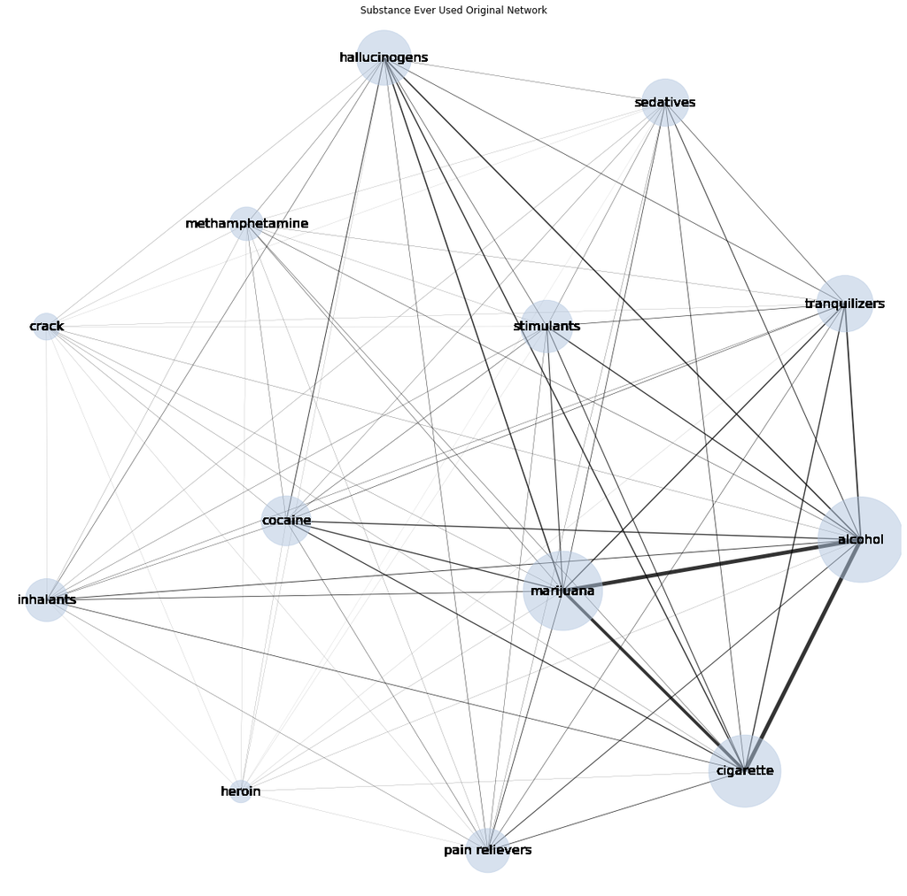

```python
ns.draw_weighted_network(graph=G_ever, weight_name='consumers', title="Substance Ever Used Original Network")
```

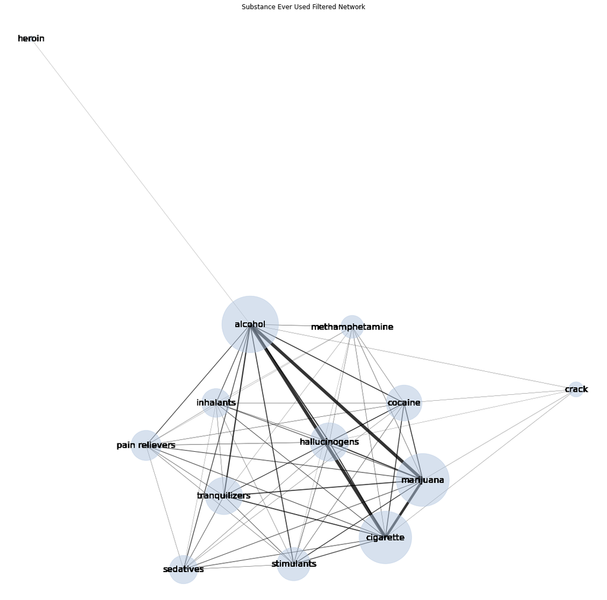

```python
ns.draw_weighted_network(graph=G_ever_filtered, weight_name='consumers', title="Substance Ever Used Filtered Network")
```

### Applied network analysis

- By using the degree centrality measure we want to know the most important substance nodes in the network with respect to the number of adjacent substances connected to them. Based on the degree of direct associations, those substances with the highest degree centrality values have a higher probability of being consumed compared to those with a lower degree value.
- The clustering coefficient allows us to allocate substance with the most/least substance node triads. the higher the clustering coefficient for a given substance, the greater the probability for accessing other substances in the triads to which it belongs

#### Substance node Degree centrality measures

The better positioned a substance is within the network, the greater its characteristic of acting as a "direct spreader" of consumption of other substances with which it is associated. To know the positioning of each node in the network, the degree centrality is calculated. This local metric evaluates the degree of relevance of the substances in isolation from the number of direct relationships they have with adjacent substances. Those substances with a high degree enjoy a high level of visibility and influence and can be considered an entry point for the consumption of other substances associated with them. The following three ways of representing the degree measure have been made available:

The first and second variants represent the number of direct relationships of each substance without considering their edge weights. The second variant is the standardized version of the first one. The third variant takes into account the weight of each edge directly associated with each pair of substances. For this case, the attribute of number of consumers in common has been associated as the weight of each edge.

The following plots show the above-mentioned degree values. Each plot includes two layers, one that refers to the original network including the self-loops and another with respect to the filtered network that excludes the self-loops and all the edges with a weight lower than 950 consumers in common. Note that in the case of the original network the number of degrees of all substances is higher than the total number of substances present in the network. This is because in this particular case the network also contains reflexive or self-loop relationships, i.e. edges that represent cases of consumers who have only consumed the particular substance.

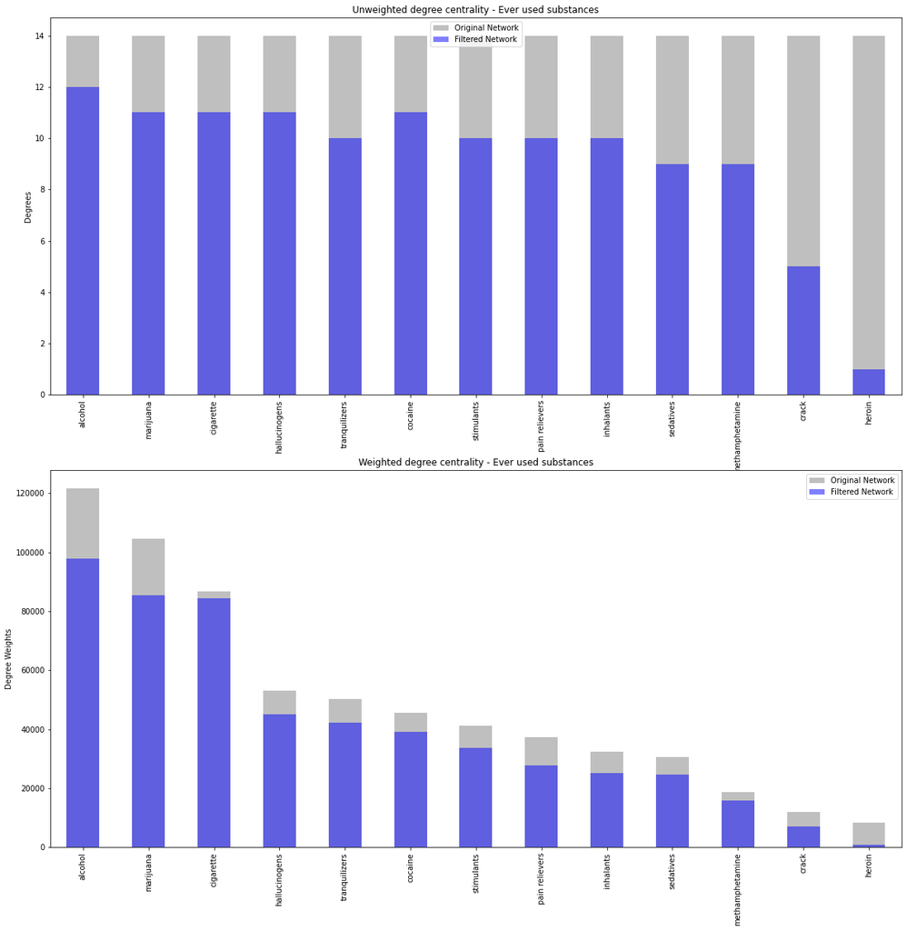

```python
fig, ax = plt.subplots(2,1,figsize=(20,20))
_ = G_ever_centrality_dfs[0]['degree'].plot(kind='bar',ax=ax[0], color='grey',alpha=0.5, label='Original Network')
_ = G_ever_centrality_dfs[1]['degree'].plot(kind='bar',ax=ax[0], color='blue',alpha=0.5, label='Filtered Network')
ax[0].legend()
ax[0].set_title("Unweighted degree centrality - Ever used substances")
ax[0].set_ylabel("Degrees")
_ = G_ever_centrality_dfs[0]['weighted_degree'].plot(kind='bar',ax=ax[1], color='grey',alpha=0.5, label='Original Network')
_ = G_ever_centrality_dfs[1]['weighted_degree'].plot(kind='bar',ax=ax[1], color='blue',alpha=0.5, label='Filtered Network')
ax[1].set_title("Weighted degree centrality - Ever used substances")
ax[1].set_ylabel("Degree Weights")
ax[1].legend()
plt.show()
```

```python
with pd.option_context('display.max_rows', None, 'display.max_columns', None):
    print("Substance Node Degree Centralities (Original Network)")
    display(G_ever_centrality_dfs[0][['weighted_degree','degree','degree_normalized']])
    print("Substance Node Degree Centralities (Filtered Network)")
    display(G_ever_centrality_dfs[1][['weighted_degree','degree','degree_normalized']])
```

```
Substance Node Degree Centralities (Original Network)
```

|  | weighted_degree | degree | degree_normalized |
| --- | --- | --- | --- |
| alcohol | 121728 | 14 | 1.166667 |
| marijuana | 104546 | 14 | 1.166667 |
| cigarette | 86750 | 14 | 1.166667 |
| tranquilizers | 53061 | 14 | 1.166667 |
| hallucinogens | 50155 | 14 | 1.166667 |
| stimulants | 45627 | 14 | 1.166667 |
| cocaine | 41309 | 14 | 1.166667 |
| sedatives | 37287 | 14 | 1.166667 |
| pain relievers | 32381 | 14 | 1.166667 |
| inhalants | 30695 | 14 | 1.166667 |
| methamphetamine | 18719 | 14 | 1.166667 |
| crack | 11880 | 14 | 1.166667 |
| heroin | 8334 | 14 | 1.166667 |

```
Substance Node Degree Centralities (Filtered Network)
```

|  | weighted_degree | degree | degree_normalized |
| --- | --- | --- | --- |
| alcohol | 97924 | 12 | 1.000000 |
| marijuana | 85511 | 11 | 0.916667 |
| cigarette | 84324 | 11 | 0.916667 |
| hallucinogens | 45069 | 11 | 0.916667 |
| tranquilizers | 42338 | 10 | 0.833333 |
| cocaine | 39191 | 11 | 0.916667 |
| stimulants | 33824 | 10 | 0.833333 |
| pain relievers | 27777 | 10 | 0.833333 |
| inhalants | 25275 | 10 | 0.833333 |
| sedatives | 24554 | 9 | 0.750000 |
| methamphetamine | 15964 | 9 | 0.750000 |
| crack | 6947 | 5 | 0.416667 |
| heroin | 952 | 1 | 0.083333 |

#### Clustering coefficient

The aim of calculating this network clustering coefficient is to evaluate the degree of cohesion(strength) of the existing links between triads of substances. This is interesting because the greater the clustering coefficient for a given substance, the greater the probability for accessing other substances in the triads to which it belongs

The cluster coefficient for a given substance (local measurement) results in a fraction in the range of 0 to 1, where 1 indicates that all its adjacent substances have direct edges to each other. The clustering coefficient can also be calculated for the whole network (global measure) and is obtained from the sum of all local clustering coefficients divided by the number of substances in the network (average clustering coefficient).

Two approaches to the calculation of clustering coefficients are presented below. The first approach refers to the unweighted clustering coefficient giving the same weight to all existing edges ($w=1$).The second uses an attribute of the edges as weight, in this case the number of consumers in common between each pair of substances. For both cases, the node specific coefficient (local measurement) and the average coefficient concerning all within the network (global measurement) have been calculated.

##### Unweighted Clustering coefficient

###### Unweighted Local Clustering Coefficient

The clustering coefficient of a substance represents the ratio of possible interconnections between the substance and its neighbors. For its calculation the following formula is used:

$$CC_{substance} = \frac{2 \cdot N_{S}}{E_{S} \cdot (E_{S}-1)}$$

Where:

$S:$ substance node

$E_{S}:$ substance node degree

$N_{S}:$Number of edges between the neighbor substances of S

For the calculation of the clustering coefficient of each substance, the algorithm `networkx.clustering(Graph)` was used.

```python
G_ever_clustering_coefficients_df = pd.DataFrame(
    dict(original_network_clustering_coeff = dict(nx.clustering(G_ever)),
         filtered_network_clustering_coeff = dict(nx.clustering(G_ever_filtered)))
)
```

The table below shows the cluster coefficients for each substance:

The cluster coefficient for each substance in the original network will always be 1. This is because each substance forms a clique in itself, that is, it is directly connected to itself through a self-loop. For this reason networkx excludes those self-loop type edges. Despite this, the cluster coefficient for each substance remains 1.0 indicating that all substances are strongly connected to each other.

In the case of the filtered network we found that only 3 of the substances investigated have a clustering of 1.0 (crack, methamphetamine, sedatives) and only 1 of the substances investigated (heroin) has a clustering of 0.0 indicating that their adjacent neighbors are not connected to each other. Alcohol appears as the second substance with the least clustering coefficient in the network, due to the incidence of its neighbor, heroin, not having any direct relation with any other substance.

```python
G_ever_clustering_coefficients_df.sort_values(by=['filtered_network_clustering_coeff'],ascending=False)
```

|  | original_network_clustering_coeff | filtered_network_clustering_coeff |
| --- | --- | --- |
| crack | 1.0 | 1.000000 |
| methamphetamine | 1.0 | 1.000000 |
| sedatives | 1.0 | 1.000000 |
| inhalants | 1.0 | 0.977778 |
| pain relievers | 1.0 | 0.977778 |
| tranquilizers | 1.0 | 0.977778 |
| stimulants | 1.0 | 0.977778 |
| cigarette | 1.0 | 0.872727 |
| marijuana | 1.0 | 0.872727 |
| cocaine | 1.0 | 0.872727 |
| hallucinogens | 1.0 | 0.872727 |
| alcohol | 1.0 | 0.727273 |
| heroin | 1.0 | 0.000000 |

###### Unweighted Global Clustering Coefficient

The unweighted global clustering coefficient assesses the strength of the network ties as a whole.

In the case of the original network the global clustering coefficient is 1.0 which means that each substance in the network is connected to each of the others, i.e. within the total sample of observations for all pairs of substances there was at least one person who had consumed both.

In the case of the filtered network, the clustering coefficient is 0.85. Even though this value is not as high as the one for the original network, it can be concluded that the network continues to have a high number of strong ties between substances, i.e., there are still many substance pairs for which at least 950 surveyed participants have stated to have consumed both substances at least once in their life.

```python
G_ever_clustering_coefficients_df.mean().to_frame().rename(columns={0:"Average Clustering Coefficient"})
```

|  | Average Clustering Coefficient |
| --- | --- |
| original_network_clustering_coeff | 1.000000 |
| filtered_network_clustering_coeff | 0.856099 |

##### Weighted Clustering Coefficient

###### Weighted local Clustering Coefficient

The problem with the calculation of the unweighted clustering coefficient using the above formula is that it does not consider the number of consumers in common for each pair of substances in the network since all the links between the substances that make up the triads have been given the same weight ($weight=1$). The weighted clustering coefficient, on the contrary, uses the weight of the edges as an additional criterion to measure the strength of the ties of a substance not only from the number of triads but also from the number of "big triads" to which it belongs.

For the calculation of the weighted clustering coefficient of each substance, the `networkx.clustering(Graph, weight='consumers')` algorithm has been used again, this time passing as a parameter the 'consumers' attribute present in each edge which constitutes its weight.

```python
G_ever_weighted_clustering_coefficients_df = pd.DataFrame(
    dict(original_network_weighted_clustering_coeff = dict(nx.clustering(G_ever, weight='consumers')),
         filtered_network_weighted_clustering_coeff = dict(nx.clustering(G_ever_filtered,weight='consumers')))
)
```

The table below shows the local weighted cluster coefficient for each substance in the network, once for the original network and once for the filtered network. In this case there is a noticeable difference from the previous calculation. It can already be noticed that the substances with the strongest ties (with the highest number of "big triads") are more similar to the results from the bar plot at the beginning of this notebook refering to the "substance ever used" consumption cases, i.e., the proportion of survey participants who have ever consumed the respective substance at least once in life (for more information you can see the exploratory analis section included in this jupyter notebook)

In this case, the original network shows alcohol as the substance with strongest ties ($CC_{alcohol} = 0.199508$) followed by marijuana ($CC_{marijuana} = 0.187175$) and cigarettes ($CC_{cigarette} = 0.184814$).

```python
G_ever_weighted_clustering_coefficients_df.sort_values(by=['original_network_weighted_clustering_coeff'],ascending=False)
```

|  | original_network_weighted_clustering_coeff | filtered_network_weighted_clustering_coeff |
| --- | --- | --- |
| alcohol | 0.199508 | 0.180330 |
| marijuana | 0.187175 | 0.202698 |
| cigarette | 0.184814 | 0.200167 |
| hallucinogens | 0.135115 | 0.144841 |
| tranquilizers | 0.129611 | 0.164335 |
| cocaine | 0.125337 | 0.133155 |
| stimulants | 0.113847 | 0.144694 |
| pain relievers | 0.103587 | 0.129467 |
| inhalants | 0.097424 | 0.121907 |
| sedatives | 0.095413 | 0.136658 |
| methamphetamine | 0.078084 | 0.103467 |
| crack | 0.058663 | 0.110526 |
| heroin | 0.047247 | 0.000000 |

###### Weighted Global Clustering Coefficient

The weighted clustering coefficients for the original network and for the filtered network are $CC_{original\ network} = 0.119679$ and $CC_{filtered\ network} = 0.136326$, respectively. In this case the number of "big triads" is less than the number of total available triads in the network,that is, a less number of triads of substances with strong consumption ties.

```python
G_ever_weighted_clustering_coefficients_df.mean().to_frame().rename(columns={0:"Average Weighted Clustering Coefficient"})
```

|  | Average Weighted Clustering Coefficient |
| --- | --- |
| original_network_weighted_clustering_coeff | 0.119679 |
| filtered_network_weighted_clustering_coeff | 0.136326 |

#### Other Network Measures

The tables below summarize the information previously analyzed along with additional measures for the analysis of both networks.

```python
with pd.option_context('display.max_rows', None, 'display.max_columns', None):
    print("Network measure Summary (Original Network)")
    display(G_ever_centrality_dfs[0])
    print("Network measure Summary (Filtered Network)")
    display(G_ever_centrality_dfs[1])
```

```
Network measure Summary (Original Network)
```

|  | degree | weighted_degree | degree_normalized | eigenvector_centrality | closeness_centrality | betweenness_centrality | cluster_coefficient | weighted_cluster_coefficient |
| --- | --- | --- | --- | --- | --- | --- | --- | --- |
| alcohol | 14 | 121728 | 1.166667 | 0.27735 | 1.0 | 0.0 | 1.0 | 0.199508 |
| marijuana | 14 | 104546 | 1.166667 | 0.27735 | 1.0 | 0.0 | 1.0 | 0.187175 |
| cigarette | 14 | 86750 | 1.166667 | 0.27735 | 1.0 | 0.0 | 1.0 | 0.184814 |
| tranquilizers | 14 | 53061 | 1.166667 | 0.27735 | 1.0 | 0.0 | 1.0 | 0.129611 |
| hallucinogens | 14 | 50155 | 1.166667 | 0.27735 | 1.0 | 0.0 | 1.0 | 0.135115 |
| stimulants | 14 | 45627 | 1.166667 | 0.27735 | 1.0 | 0.0 | 1.0 | 0.113847 |
| cocaine | 14 | 41309 | 1.166667 | 0.27735 | 1.0 | 0.0 | 1.0 | 0.125337 |
| sedatives | 14 | 37287 | 1.166667 | 0.27735 | 1.0 | 0.0 | 1.0 | 0.095413 |
| pain relievers | 14 | 32381 | 1.166667 | 0.27735 | 1.0 | 0.0 | 1.0 | 0.103587 |
| inhalants | 14 | 30695 | 1.166667 | 0.27735 | 1.0 | 0.0 | 1.0 | 0.097424 |
| methamphetamine | 14 | 18719 | 1.166667 | 0.27735 | 1.0 | 0.0 | 1.0 | 0.078084 |
| crack | 14 | 11880 | 1.166667 | 0.27735 | 1.0 | 0.0 | 1.0 | 0.058663 |
| heroin | 14 | 8334 | 1.166667 | 0.27735 | 1.0 | 0.0 | 1.0 | 0.047247 |

```
Network measure Summary (Filtered Network)
```

|  | degree | weighted_degree | degree_normalized | eigenvector_centrality | closeness_centrality | betweenness_centrality | cluster_coefficient | weighted_cluster_coefficient |
| --- | --- | --- | --- | --- | --- | --- | --- | --- |
| alcohol | 12 | 97924 | 1.000000 | 0.312001 | 1.000000 | 0.186532 | 0.727273 | 0.180330 |
| marijuana | 11 | 85511 | 0.916667 | 0.309206 | 0.923077 | 0.019865 | 0.872727 | 0.202698 |
| cigarette | 11 | 84324 | 0.916667 | 0.309206 | 0.923077 | 0.019865 | 0.872727 | 0.200167 |
| hallucinogens | 11 | 45069 | 0.916667 | 0.309206 | 0.923077 | 0.019865 | 0.872727 | 0.144841 |
| tranquilizers | 10 | 42338 | 0.833333 | 0.295335 | 0.857143 | 0.001684 | 0.977778 | 0.164335 |
| cocaine | 11 | 39191 | 0.916667 | 0.309206 | 0.923077 | 0.019865 | 0.872727 | 0.133155 |
| stimulants | 10 | 33824 | 0.833333 | 0.295335 | 0.857143 | 0.001684 | 0.977778 | 0.144694 |
| pain relievers | 10 | 27777 | 0.833333 | 0.295335 | 0.857143 | 0.001684 | 0.977778 | 0.129467 |
| inhalants | 10 | 25275 | 0.833333 | 0.295335 | 0.857143 | 0.001684 | 0.977778 | 0.121907 |
| sedatives | 9 | 24554 | 0.750000 | 0.270884 | 0.800000 | 0.000000 | 1.000000 | 0.136658 |
| methamphetamine | 9 | 15964 | 0.750000 | 0.270884 | 0.800000 | 0.000000 | 1.000000 | 0.103467 |
| crack | 5 | 6947 | 0.416667 | 0.153674 | 0.631579 | 0.000000 | 1.000000 | 0.110526 |
| heroin | 1 | 952 | 0.083333 | 0.030957 | 0.521739 | 0.000000 | 0.000000 | 0.000000 |

## Substance used in last 30 days Network

Throughout this second section, the network of substances used by the participants in the last 30 days will be analyzed.

### Network Characteristics

The "substance used in last 30 days" network is an undirected one-mode network containing the following characteristics:

| Node Type | Substance |
| --- | --- |
| Edge Meaning | Substance A and substance B have been consumed by the same person within the last 30 days |
| Number of Substance Nodes | 13 |
| Number of Edges | 91 |
| Average Degree | 14 |

**Self loop relationships**

Once again, the existence of self loop relationships for the investigated substance nodes in the network is reported, that is, cases of people who have consumed only one of the indicated substances during the last month. The algorithms created for this project allow by default the calculation of these self-loop relationships.

### Filters applied to the network

For the creation of the network, only individual observations with cases of last 30 day consumption of at least one of the indicated substances have been taken into account.

### Graphical Network Representation

the following is a network graph of substances consumed during the last 30 days

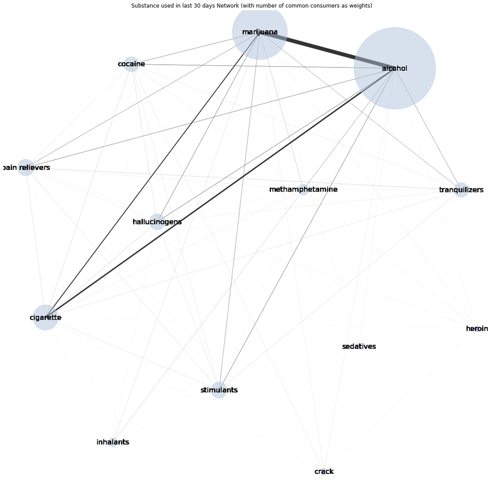

```python
# The original network of substances used in last 30 days
G_substance_used_in_last30_days = ns.substance_used_in_last_30d_network(dataframe)
ns.draw_weighted_network(graph=G_substance_used_in_last30_days, weight_name='consumers', title="Substance used in last 30 days Network (with number of common consumers as weights)")
```

### Applied network analysis

#### Eigenvector centrality

By means of eigenvector centrality we want to know the level of importance for each substance based on the importance of its adjacent substances. The degree of importance of a node substance is given by the sum of the weight values each of its neighboring substances have.

The degree of importance of a substance applying eigenvector centrality can be calculated using the attributes of the edges it has. Each edge attribute represents the number of common occurrences (weights) for a specific characteristic (such as number of common consumers) a pair of substances share. The level of importance of substances based on any individual edge attributes will be calculated and listed. Finally some comments related to any of the eigenvector outcomes will be presented.

The following is a list of the available attributes of an edge belonging to a pair of substances. The weight attributes are related to the common characteristics of mood during the last month, poverty level, age category and proportion of consumption among the total number of participants tied to them.

```python
attributes = list(list(G_substance_used_in_last30_days.edges(data=True))[0])
print('Edge between ',attributes[0],' and ',attributes[1],'\n\n  Common Attributes:\n')
a = [" - " + str(k) + "("+ str(v) + " occurences)" for k,v in attributes[2].items()]
print(*a,sep='\n')
```

```
Edge between  cigarette  and  alcohol

  Common Attributes:

 - felt down, no good or worthless in past month None of the time(957 occurences)
 - felt down, no good or worthless in past month A little of the time(399 occurences)
 - felt down, no good or worthless in past month Most of the time(118 occurences)
 - felt down, no good or worthless in past month Some of the time(286 occurences)
 - felt down, no good or worthless in past month All of the time(93 occurences)
 - poverty level Income More Than 2X Fed Pov Thresh(1168 occurences)
 - poverty level Income Up to 2X Fed Pov Thresh(398 occurences)
 - poverty level Living in Poverty(368 occurences)
 - age category 26 - 34 Years Old(461 occurences)
 - age category 18 - 25 Years Old(848 occurences)
 - age category 35 - 49 Years Old(369 occurences)
 - age category 50 - 64 Years Old(129 occurences)
 - age category 12 - 17 Years Old(103 occurences)
 - age category 65 or Older(52 occurences)
 - consumers(1962 occurences)
 - weight(1 occurences)
```

The following table shows the calculation of the eigenvector centrality for each substance according to each of the previously mentioned edge attributes.

```python
attributes = list(list(G_substance_used_in_last30_days.edges(data=True))[0][-1].keys())
eigenvector_centralities = [nx.eigenvector_centrality(G_substance_used_in_last30_days, weight=attribute) for attribute in attributes]
eigenvector_centralities_df = pd.DataFrame(eigenvector_centralities, index=attributes)
eigenvector_centralities_df.T[['felt down, no good or worthless in past month None of the time','felt down, no good or worthless in past month All of the time']]
```

|  | felt down, no good or worthless in past month None of the time | felt down, no good or worthless in past month All of the time |
| --- | --- | --- |
| cigarette | 0.085993 | 0.218665 |
| alcohol | 0.970667 | 0.681060 |
| marijuana | 0.223273 | 0.681561 |
| cocaine | 0.012865 | 0.084686 |
| crack | 0.001072 | 0.025261 |
| heroin | 0.000501 | 0.010134 |
| hallucinogens | 0.011606 | 0.068733 |
| inhalants | 0.002381 | 0.009300 |
| methamphetamine | 0.003449 | 0.031635 |
| pain relievers | 0.010241 | 0.067116 |
| tranquilizers | 0.006061 | 0.063878 |
| stimulants | 0.009883 | 0.038552 |
| sedatives | 0.001185 | 0.004682 |

When analyzing the importance of substances according to the mental health status of the consumers (felt down, no good or worthless in past month) during the last month, it can be seen that for the case of response "None of the time" alcohol is the most important substance of consumption ($eigenvector_{alcohol} = 0.97$) followed by marijuana($eigenvector_{marijuana} = 0.22$) and cigarette($eigenvector_{cigarette} = 0.085$). On the contrary, when analyzing the case for "All of the time" it can be seen that marijuana is the most important substance for consumption ($eigenvector_{marijuana} = $0.6815) followed by alcohol ($eigenvector_{alcohol} = $0.6810) and cigarettes ($eigenvector_{marijuana} = $0.2186). These numbers could indicate that participants who did not report mental health issues are most often drawn to consume alcohol, marijuana and cigarettes - the most frequently used substances overall, irrespective of other attributes of the participants. However, participants who seemed to present with serious mental health issues consumed most often marijuana. Marijuana could thus be seen by participants with mental health issues as the substance that is most effective in helping with their negative emotions. Another interpretation would be that more frequent marijuana consumption can cause more serious mental health issues (than, for instance, frequent drinking or cigarette smoking).

## Substance Consumers in last 30 days Network

In the past sections we analyzed the substance networks of "substance ever used" and "substances used in last month". The following section covers the network analysis of people who have consumed any common substances with other people during the past month.

### Network Characteristics

The Substance Consumers in last 30 days Network is a undirected one-mode network of people tied together by the number of common substances consumed during the past month.

| Nodes | People |
| --- | --- |
| Edge | Person A has consumed at least one substance in common as Person B during the past month |
| Number of nodes | 384 |
| Number of edges | 57232 |

### Filters applied to the network

- It is important to note that the network only includes people with ethnicity/race being Native American, Native Alaskan, Native Hawaiian or other Pacific Islander (Samoans, Chamorros, Fijians, Palauans and Tongans) who have stated that they have consumed at least one of the substances investigated during the last thirty days prior to the survey. This reduction to small participant groups was undertaken to reduce the sample size for analysis and thus the number of nodes.
- The network also considers those people nodes having at least one common substance relationship with any other in the network

### Graphical Network Representation

the following is a network graph representing the consumers of at least 1 substance within the last 30 days

```python
# Only includes Native americans, native alaskans, native hawaiians, other pacific islanders (Samoans, Chamorros, Fijians, Palauans and Tongans)
people_network = ns.people_network(dataframe=dataframe, include_zero_substances_used_relationships=False, include_nodes_with_zero_substances_used=False)
```

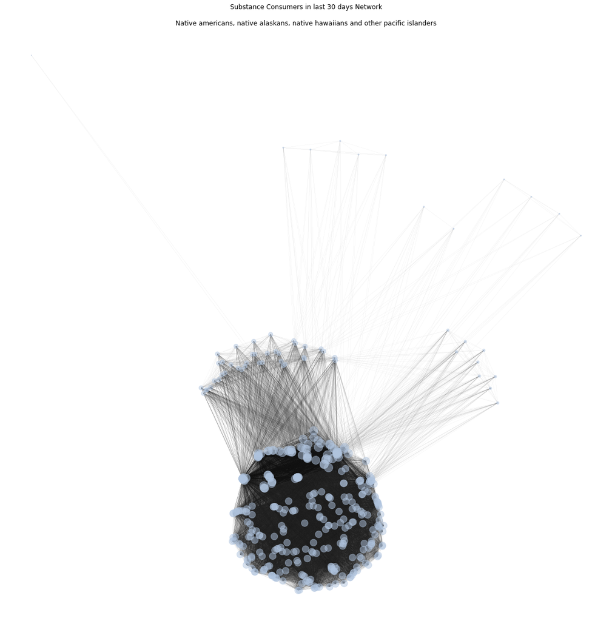

```python
ns.draw_weighted_network(graph=people_network, weight_name='number of common substances', title="Substance Consumers in last 30 days Network\n\nNative americans, native alaskans, native hawaiians and other pacific islanders", labels=False)
```

### Applied network analysis

#### Link Prediction

The network of people who "share" the use of at least one of the substances during the past month is already known. Now it is interesting to make a prediction of those links between those people pairs that do not exist yet but are most likely to be formed in the future. We proceed to predict such links by using the jaccard coefficient and common neighbors link prediction algorithms.

##### Common neighbors

The common neighbors algorithm allows to calculate the likelihood of future common substance used links between people that are not linked togheter by considering the number of common neighbors among them. Those pairs of consumers with the highest number of common neighbors get a higher probability of being directly linked to each other (by consuming a common substance) in the future.

```python
def sort_values_and_get_dataframe (lst, algorithm):
    sorted_list = sorted(lst,key=lambda x: x[2], reverse=True)
    return pd.DataFrame(sorted_list).rename(columns={0:"Consumer A", 1:"Consumer B",2:algorithm})

# Common neighbors
common_neighbors = [(nodes[0], nodes[1],len(list(nx.common_neighbors(people_network, nodes[0],nodes[1])))) for nodes in nx.non_edges(people_network)]
common_neighbors_df = sort_values_and_get_dataframe(common_neighbors,"common neighbors")
common_neighbors_df.head(10)
```

|  | Consumer A | Consumer B | common neighbors |
| --- | --- | --- | --- |
| 0 | 33442 | 7714 | 109 |
| 1 | 33442 | 55837 | 109 |
| 2 | 33442 | 15070 | 109 |
| 3 | 33442 | 16474 | 109 |
| 4 | 15070 | 42126 | 109 |
| 5 | 55837 | 42126 | 109 |
| 6 | 7714 | 42126 | 109 |
| 7 | 42126 | 16474 | 109 |
| 8 | 33442 | 55328 | 107 |
| 9 | 55328 | 42126 | 107 |

The following shows the substances that might connect a pair of consumer nodes in the future (that is, the substances most likely to be consumed by consumer a and those by consumer b in the future)

```python
strings = ns.substance_predictions(dataframe, common_neighbors_df[:4])
print("Most predicted substance use using the common neighbors algorithm:\n")
for string in strings:
    print(string)
```

```
Most predicted substance use using the common neighbors algorithm:

Predicted substances for:
  - Consumer id 33442: ['alcohol', 'pain relievers']
  - Consumer id 7714: ['cigarette', 'marijuana']
  - common neighbors: 109
Predicted substances for:
  - Consumer id 33442: ['alcohol', 'methamphetamine']
  - Consumer id 55837: ['cigarette', 'marijuana']
  - common neighbors: 109
Predicted substances for:
  - Consumer id 33442: ['alcohol', 'methamphetamine', 'stimulants']
  - Consumer id 15070: ['cigarette', 'marijuana']
  - common neighbors: 109
Predicted substances for:
  - Consumer id 33442: ['alcohol', 'pain relievers']
  - Consumer id 16474: ['cigarette', 'marijuana']
  - common neighbors: 109
```

#### Jaccard Coefficient

Using Jaccard Coefficient, the relationship of two unlinked nodes is predicted from the ratio that results from dividing the total number of neighbors in common between the nodes by the total number of neighbors of both nodes. The higher the jaccard coefficient for any pair of nodes, the higher the likelihood that they will form links. In the present dataset, a high Jaccard coefficient means that consumer A and consumer B are likely to develop similar substance use patterns that will link them.

```python
jaccard_coefficient = list(nx.jaccard_coefficient(people_network))
jaccard_coefficient_df = sort_values_and_get_dataframe(jaccard_coefficient, "jaccard coefficient")
jaccard_coefficient_df.head(10)
```

|  | Consumer A | Consumer B | jaccard coefficient |
| --- | --- | --- | --- |
| 0 | 33442 | 55837 | 0.293011 |
| 1 | 33442 | 15070 | 0.293011 |
| 2 | 15070 | 42126 | 0.293011 |
| 3 | 55837 | 42126 | 0.293011 |
| 4 | 33442 | 7714 | 0.290667 |
| 5 | 33442 | 16474 | 0.290667 |
| 6 | 7714 | 42126 | 0.290667 |
| 7 | 42126 | 16474 | 0.290667 |
| 8 | 33442 | 55328 | 0.289189 |
| 9 | 55328 | 42126 | 0.289189 |

```python
strings = ns.substance_predictions(dataframe,jaccard_coefficient_df[:1])
print("Predicted substance use using jaccard coefficient algorithm\n")
for string in strings:
    print(string)
```

```
Predicted substance use using jaccard coefficient algorithm

Predicted substances for:
  - Consumer id 33442: ['alcohol', 'methamphetamine']
  - Consumer id 55837: ['cigarette', 'marijuana']
  - jaccard coefficient: 0.29301075268817206
```